# Part II - (Ford GoBike System Data)

## Dataset Overview

The dataset consists of bicycle trip records (shared from the Ford GoBike System Data) and is described as follows:  
It contains trip information, the time of the trip, the time and date of the start of the trip, the station information, the type of users, the gender of the users, the age of the users, as well as the participation of the users of the information and the bike number.

```python
# import all packages and set plots to be embedded inline
import numpy as np
import pandas as pd
import matplotlib
import matplotlib.pyplot as plt
import seaborn as sb
%matplotlib inline
from matplotlib import rcParams
import datetime





# suppress warnings from final output
import warnings
warnings.simplefilter("ignore")
```

```python
# load in the dataset into a pandas dataframe
df_bike = pd.read_csv('201902-fordgobike-tripdata-clean.csv')
```

> Note that the above cells have been set as "Skip"-type slides. That means that when the notebook is rendered as http slides, those cells won't show up.

customer journey duration increases significantly on weekends and Mondays, while subscribers get a slight increase.

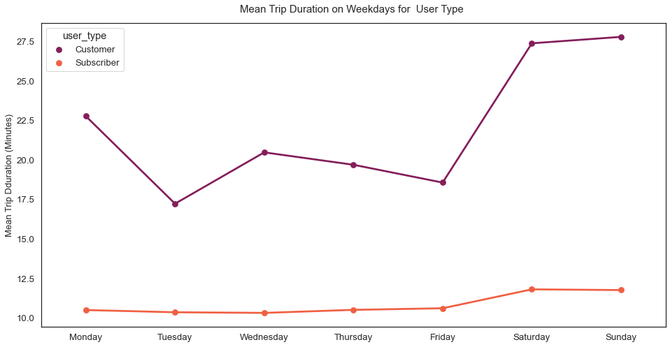

```python
# Define the size of the drawing
fig = plt.figure(figsize = [16,8])

# Drawing texts are much larger
sb.set(font_scale=1.2)
# remove the grey background
sb.set_style(style='white')
sb.pointplot(data = df_bike, x = 'day', y = 'duration_min', hue = 'user_type', palette = 'rocket', ci=None)

plt.title('Mean Trip Duration on Weekdays for  User Type ', fontsize=15,pad=15)
plt.ylabel('Mean Trip Dduration (Minutes)', fontsize=13)
plt.xlabel('')
plt.show();
```

## 2: Mean Trip Duration of the Weekdays with the Member Gender

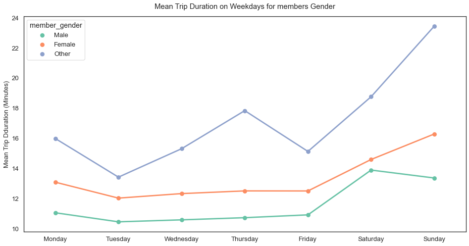

```python
# Define the size of the drawing
fig = plt.figure(figsize = [16,8])

# Drawing texts are much larger
sb.set(font_scale=1.2)

# remove the grey background
sb.set_style(style='white')
#
sb.pointplot(data = df_bike, x = 'day', y = 'duration_min', hue = 'member_gender',order=['Monday','Tuesday','Wednesday','Thursday','Friday','Saturday','Sunday'], palette="Set2", ci=None)

plt.title('Mean Trip Duration on Weekdays for members Gender', fontsize=15,pad=15)
plt.ylabel('Mean Trip Dduration (Minutes)', fontsize=13)
plt.xlabel('')
plt.show();
```